# MovieLens Data sets

## Can we trust the ratings of movies to be unbiased?

Watching movies is one of the most popular pasttimes today. There are so many movies being released for streaming every year, and it is impossible to keep up with all of them. When someone is looking for a new movie to watch, he/she will often turn to movie-related sites, like IMDB or rotten tomatoes, which aggregate ratings, reviews, and other information about movies. One of the most important factors influencing one's decision to watch a movie is the overall rating. However, does the rating reasonably represent the entire population's opinion of the movie?

To address this question, I will use the enormous MovieLens data sets (http://movielens.org), which is collected by GroupLens Research (https://grouplens.org/datasets/movielens/). This dataset consists of more than 20 million ratings of nearly 30,000 movies, with around 130,000 users.

Let's start! First, let's import the python modules we need.

```python
import pandas as pd
from pandas import Series,DataFrame
import numpy as np
import matplotlib.pyplot as plt
import seaborn as sns
import re
import warnings
warnings.filterwarnings('ignore')
sns.set_style('whitegrid')
plt.rcParams['figure.figsize'] = (12, 8)
plt.rc('xtick',labelsize=14)
plt.rc('ytick',labelsize=14)
%matplotlib inline
```

Next, I read two files, movies.csv and ratings.csv.

```python
Movie = pd.read_csv('movies.csv')
Rating = pd.read_csv('ratings.csv')
print(Movie.shape)
print(Rating.shape)
```

```
(27278, 3)
(20000263, 4)
```

```python
Rating.head(3)
```

|  | userId | movieId | rating | timestamp |
| --- | --- | --- | --- | --- |
| 0 | 1 | 2 | 3.5 | 1112486027 |
| 1 | 1 | 29 | 3.5 | 1112484676 |
| 2 | 1 | 32 | 3.5 | 1112484819 |

```python
len(pd.unique(Rating['userId']))
```

```
138493
```

The total number of users who reviewed movies is 138,493. Now, let's explore some of the information about the movies in this dataset.

```python
Movie.head(3)
```

|  | movieId | title | genres |
| --- | --- | --- | --- |
| 0 | 1 | Toy Story (1995) | Adventure\|Animation\|Children\|Comedy\|Fantasy |
| 1 | 2 | Jumanji (1995) | Adventure\|Children\|Fantasy |
| 2 | 3 | Grumpier Old Men (1995) | Comedy\|Romance |

The title for every movie automatically has the year it was released at the end. I want to separate the title from year.

```python
Movie['Title'] = Movie['title'].apply(lambda x:x.split(' (')[0])
Movie['Year'] = Movie['title'].apply(lambda x:re.findall(r"\([0-9]{4,7}\)", x))
Movie['Year'] = Movie['Year'].apply(lambda x:''.join(x))
Movie['genres']=Movie['genres'].apply(lambda x:re.sub("Sci-Fi", "SciFi", x))
Movie['genres']=Movie['genres'].apply(lambda x:re.sub("Film-Noir", "FilmNoir", x))
```

Now, I can look at the distribution of years that these movies were released.

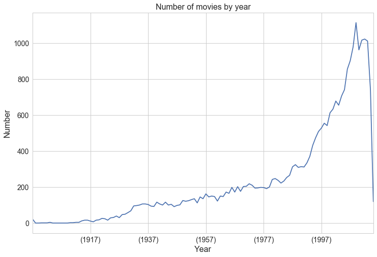

```python
Movie.groupby('Year').count()['title'].plot(figsize=(12,8),fontsize=14)
plt.title('Number of movies by year',size=16)
plt.ylabel('Number',fontsize=16)
plt.xlabel('Year',fontsize=16)
```

The reason why the trend drops at the present is because this data doesn't include the end of the year. For more detailed analysis, let's try to distinguish movies by genre.

A given movie can have multiple genres. As the table above shows, the genres are separated by vertical lines. So, I want to one-hot encode the genre to make it easier to analyze movies as a function of their genre. I also want to get rid of 'IMAX' and '(no genres listed)'

```python
GenreList = ['Action','Adventure','Animation','Children','Comedy',
             'Crime','Documentary','Drama','Fantasy','FilmNoir',
             'Horror','Musical','Mystery','Romance','SciFi',
             'Thriller','War','Western','IMAX','(no genres listed)']

GenreTable = pd.DataFrame(np.zeros((len(Movie),len(GenreList))),columns=GenreList)
MovieGenre = pd.concat([Movie,GenreTable],axis=1)
MovieGenre = MovieGenre.copy()
for j in MovieGenre.index:
    temp = MovieGenre['genres'][j].split('|')
    MovieGenre.loc[j,temp]=1

MovieGenre.columns=[['movieId','title','genres','Title','Year',
                     'Action','Adventure','Animation','Children','Comedy',
                     'Crime','Documentary','Drama','Fantasy','FilmNoir',
                     'Horror','Musical','Mystery','Romance','SciFi',
                     'Thriller','War','Western','IMAX','(no genres listed)']]

del MovieGenre['IMAX']
del MovieGenre['(no genres listed)']

MovieGenre.head(3)
```

|  | movieId | title | genres | Title | Year | Action | Adventure | Animation | Children | Comedy | ... | Fantasy | FilmNoir | Horror | Musical | Mystery | Romance | SciFi | Thriller | War | Western |
| --- | --- | --- | --- | --- | --- | --- | --- | --- | --- | --- | --- | --- | --- | --- | --- | --- | --- | --- | --- | --- | --- |
| 0 | 1 | Toy Story (1995) | Adventure\|Animation\|Children\|Comedy\|Fantasy | Toy Story | (1995) | 0.0 | 1.0 | 1.0 | 1.0 | 1.0 | ... | 1.0 | 0.0 | 0.0 | 0.0 | 0.0 | 0.0 | 0.0 | 0.0 | 0.0 | 0.0 |
| 1 | 2 | Jumanji (1995) | Adventure\|Children\|Fantasy | Jumanji | (1995) | 0.0 | 1.0 | 0.0 | 1.0 | 0.0 | ... | 1.0 | 0.0 | 0.0 | 0.0 | 0.0 | 0.0 | 0.0 | 0.0 | 0.0 | 0.0 |
| 2 | 3 | Grumpier Old Men (1995) | Comedy\|Romance | Grumpier Old Men | (1995) | 0.0 | 0.0 | 0.0 | 0.0 | 1.0 | ... | 0.0 | 0.0 | 0.0 | 0.0 | 0.0 | 1.0 | 0.0 | 0.0 | 0.0 | 0.0 |

3 rows × 23 columns

Thus, the 18 genres I consider are listed below:

- Action
- Adventure
- Animation
- Children
- Comedy
- Crime
- Documentary
- Drama
- Fantasy
- FilmNoir
- Horror
- Musical
- Mystery
- Romance
- SciFi
- Thriller
- War
- Western

Let's now check the distribution of years that the movies for each genre were released.

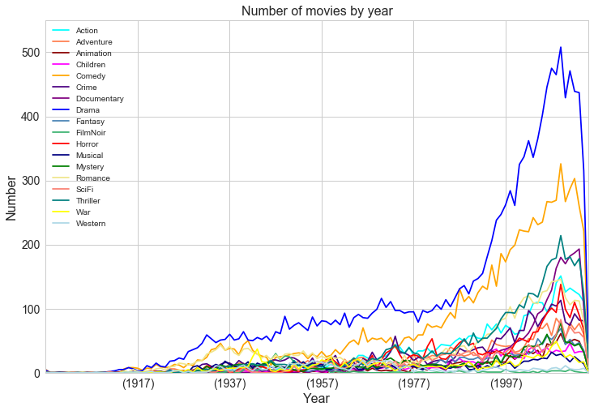

```python
GenreListAll = ['Action','Adventure','Animation','Children','Comedy',
                'Crime','Documentary','Drama','Fantasy','FilmNoir',
                'Horror','Musical','Mystery','Romance','SciFi',
                'Thriller','War','Western']

c = ['aqua',  'coral','darkred','magenta','orange',
     'indigo','#800080','blue','#4682B4','mediumseagreen',
     'red','navy', 'green','khaki', 'salmon', 'teal',
     'yellow', 'lightblue']

c_dic={}
for i in range(len(GenreListAll)):
    c_dic[GenreListAll[i]]=c[i]

MovieGenre.groupby('Year').sum()[GenreListAll].plot(ylim=(0,550),figsize=(12,8),color=c)
plt.title('Number of movies by year',size=16)
plt.ylabel('Number',fontsize=16)
plt.xlabel('Year',fontsize=16)
```

Drama and Comedy films clearly vastly outnumber all the other genres! The plot above only demonstrates the relative popularity of different genres over time. Now, I want to see the total number for each genre I am considering.

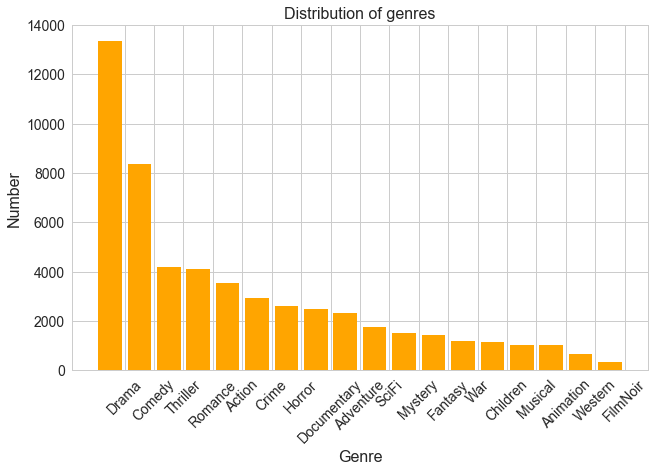

```python
Result = MovieGenre[GenreListAll].sum()
x = np.arange(len(Result.index))
f = plt.figure(figsize=(10,6))
ax = f.add_axes([0.1, 0.1, 0.8, 0.8])
ax.bar(x, Result.sort_values(ascending=False).values ,color='orange')
ax.set_xticks(x+0.5)
ax.set_xticklabels(Result.sort_values(ascending=False).index,rotation=45)
plt.xlabel('Genre',fontsize=16)
plt.ylabel('Number',fontsize=16)
plt.title('Distribution of genres',fontsize=16)
f.show()
```

The above bar-plot shows the total number of movies for each genre. Drama and Comedy are the most dominant genres, which means that many people like watching movies of these genres, and so it is likely that producers try to make these types of films more frequently. Note that the total number of movies in the figure above is greater than the previous movie distribution plot because movies are counted multiple times if they have multiple genres.

```python
MovieRating = pd.merge(MovieGenre,Rating,on='movieId')
MovieRating.head(3)
```

|  | movieId | title | genres | Title | Year | Action | Adventure | Animation | Children | Comedy | ... | Musical | Mystery | Romance | SciFi | Thriller | War | Western | userId | rating | timestamp |
| --- | --- | --- | --- | --- | --- | --- | --- | --- | --- | --- | --- | --- | --- | --- | --- | --- | --- | --- | --- | --- | --- |
| 0 | 1 | Toy Story (1995) | Adventure\|Animation\|Children\|Comedy\|Fantasy | Toy Story | (1995) | 0.0 | 1.0 | 1.0 | 1.0 | 1.0 | ... | 0.0 | 0.0 | 0.0 | 0.0 | 0.0 | 0.0 | 0.0 | 3 | 4.0 | 944919407 |
| 1 | 1 | Toy Story (1995) | Adventure\|Animation\|Children\|Comedy\|Fantasy | Toy Story | (1995) | 0.0 | 1.0 | 1.0 | 1.0 | 1.0 | ... | 0.0 | 0.0 | 0.0 | 0.0 | 0.0 | 0.0 | 0.0 | 6 | 5.0 | 858275452 |
| 2 | 1 | Toy Story (1995) | Adventure\|Animation\|Children\|Comedy\|Fantasy | Toy Story | (1995) | 0.0 | 1.0 | 1.0 | 1.0 | 1.0 | ... | 0.0 | 0.0 | 0.0 | 0.0 | 0.0 | 0.0 | 0.0 | 8 | 4.0 | 833981871 |

3 rows × 26 columns

The above table shows the combined datasets when I merge the movie table with the users and their ratings. Now, it is possible to track users behavior in their ratings. So, one way I could explore potential bias in a user's ratings is to assess whether a fan of a certain genre will rate movies of that genre higher/lower than the general public. First we need to define what is a fan of a genre.

Before going any further, I chose only the users who have rated at least one hundred movies (which represents the top 50,000 most active users).

```python
MovieRating1 = MovieRating.copy()
temp = MovieRating1.groupby('userId').sum()[GenreListAll]
UserIdGenre1 = pd.DataFrame(temp.values/pd.DataFrame(temp.T.sum()).values,columns=GenreListAll,index=temp.index)
UserIdGenre1['TotalNumber']=MovieRating1.groupby('userId').count()['movieId']
CriteriaUserIdGenre1 = pd.DataFrame(UserIdGenre1.sort_values('TotalNumber',ascending=False).head(50000))
```

## How can we define a group of fans for each genre?

Selecting the fans for each genre is a tough mission. In this project, I define fans for each genre as people who reviewed the specific genre more frequently compared to movies of other genres. For example, considering a person (person A) reviewed 1,000 movies in the dataset, and person A reviewed 300 SciFi movies out of the 1,000 they reviewed. I would consider person A to be a fan of SciFi (For the average person, SciFi movies only account for 6% of the movies they rated).

I will explain in detail in the charts below.

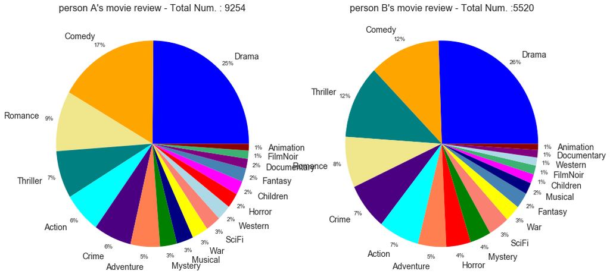

```python
fig = plt.figure(figsize=(16,8))
ax=fig.add_subplot(121)
contents = CriteriaUserIdGenre1[GenreListAll].iloc[0].sort_values(ascending=False)
num = CriteriaUserIdGenre1['TotalNumber'].iloc[0]
plt.pie(contents, labels=contents.index,
        colors=[c_dic.get(key) for key in contents.index.values],
        autopct='%1.0f%%', pctdistance=1.1, labeldistance=1.2)
ax.set_title("person A's movie review - Total Num. : "+str(num),fontsize=16)

ax=fig.add_subplot(122)
contents = CriteriaUserIdGenre1[GenreListAll].iloc[3].sort_values(ascending=False)
num = CriteriaUserIdGenre1['TotalNumber'].iloc[3]
plt.pie(contents, labels=contents.index,
        colors=[c_dic.get(key) for key in contents.index.values],
        autopct='%1.0f%%', pctdistance=1.1, labeldistance=1.2)
ax.set_title("person B's movie review - Total Num. :"+str(num),fontsize=16)
```

The pie chart above is an example of two people's genre distributions for all the movies they rated. The reason why Drama and Comedy are more dominant than other genres is because there are many movies in these genres. The high fraction for drama and comedy does not neccesarily mean that they are fans of Drama or Comedy, but might simply reflect the fact that these genres are so prevalent. The charts above are pretty typical of an average users voting habits in the MovieLens database.

Now, let's look at a few outliers. The chart below shows the rating distributions for people who appear to be fans of Horror movies.

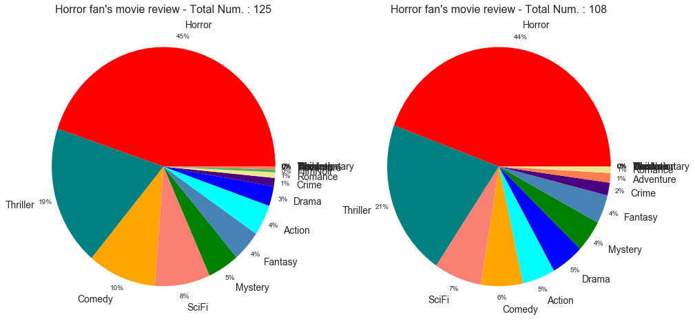

```python
fig = plt.figure(figsize=(16,8))
ax=fig.add_subplot(121)
idnum = CriteriaUserIdGenre1[GenreListAll].sort_values('Horror',ascending=False).index[0]
contents = CriteriaUserIdGenre1[CriteriaUserIdGenre1.index==idnum][GenreListAll].iloc[0].sort_values(ascending=False)
num = CriteriaUserIdGenre1[CriteriaUserIdGenre1.index==idnum]['TotalNumber'].iloc[0]
plt.pie(contents, labels=contents.index,
        colors=[c_dic.get(key) for key in contents.index.values],
        autopct='%1.0f%%', pctdistance=1.1, labeldistance=1.2)
ax.set_title("Horror fan's movie review - Total Num. : "+str(num),fontsize=16)

ax=fig.add_subplot(122)
idnum = CriteriaUserIdGenre1[GenreListAll].sort_values('Horror',ascending=False).index[1]
contents = CriteriaUserIdGenre1[CriteriaUserIdGenre1.index==idnum][GenreListAll].iloc[0].sort_values(ascending=False)
num = CriteriaUserIdGenre1[CriteriaUserIdGenre1.index==idnum]['TotalNumber'].iloc[0]
plt.pie(contents, labels=contents.index,
        colors=[c_dic.get(key) for key in contents.index.values],
        autopct='%1.0f%%', pctdistance=1.1, labeldistance=1.2)
ax.set_title("Horror fan's movie review - Total Num. : "+str(num),fontsize=16)
```

As seen in the chart above, the distribution is very different from the previous plots. In the case of these people, I will consider them to be fans of horror movies.

I selected fans of each genre following the steps below:

1. Start by looking at the relative fraction of ratings by genre for the overall population. Then, it stands to reason that someone who is a fan of a certain genre, and who watches a disproportionately large fraction of movies in that genre, would rate movies in that genre more frequently than the average person does.
2. Look for outliers who rated movies of that genre at a much higher frequency than the overall population.

The box-plot below shows the typical range of percentages of certain genres that users reviewed.

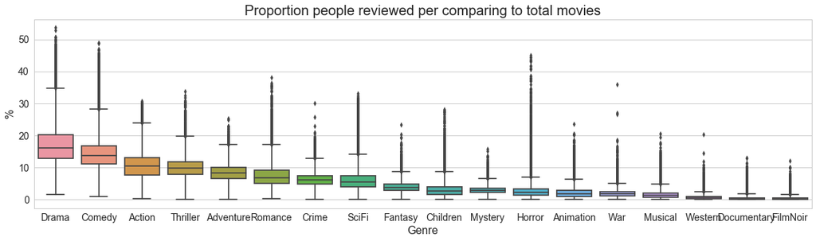

```python
plt.figure(figsize=(20,5))
sns.boxplot(data=CriteriaUserIdGenre1[GenreListAll]*100,orient='v',
            order=CriteriaUserIdGenre1[GenreListAll].sum().sort_values(ascending=False).index,
           whis=2)
plt.ylabel('%',fontsize=16)
plt.xlabel('Genre',fontsize=16)
plt.title('Proportion people reviewed per comparing to total movies',size=20)
```

The colored boxes in the box-plot above highlight the 25%-75% range of the distribution for each genre that people reviewed. The upper whiskers corresponds to the top 1% of the distribution. Based on this information, I consider a fan to be a person who is identified as an outlier above the upper whiskers for each genre. For example, if someone has rated drama movies at more than 35%, I would define this person as a fan of drama (Look at the box graph for drama). Therefore, I chose 500 people (1% of total sample of 50,000) for each genre as the group of fans for that genre.

```python
for j in np.arange(len(GenreListAll)):
    name1='Group1'+str(GenreListAll[j])
    name2='Group2'+str(GenreListAll[j])
    exec(name1+"= pd.DataFrame(CriteriaUserIdGenre1.sort_values(GenreListAll[j],ascending=False).head(500).index)")
    exec(name2+"= pd.DataFrame(CriteriaUserIdGenre1.sort_values(GenreListAll[j],ascending=False).tail(49500).index)")
    exec(name1+".columns=['userId']")
    exec(name2+".columns=['userId']")
```

The script below derives the average ratings for each movie by fans of the genre and by non-fans. For the 18 genre categories, I chose the 30 movies which have the most total reviews and have at least 100 reviews from fans of the genre. **The script below takes a long time to run (Here, I deleted the output cell in order to avoid confusion).**

```python
CountMovieRating = MovieRating.groupby('title').sum()
for j in np.arange(len(GenreListAll)):
    temp = CountMovieRating.sort_values(GenreListAll[j],ascending=False)
    exec('Result'+str(GenreListAll[j])+'=DataFrame()')
    i=0; n=0
    while n<=30:
        name = temp.index[i]
        exec('G1 = pd.merge(Group1'+str(GenreListAll[j])+''',MovieRating[MovieRating['title']==name][['userId','rating']],on='userId',how='inner')''')
        if len(G1) >=100:
            exec('G2 = pd.merge(Group2'+str(GenreListAll[j])+''',MovieRating[MovieRating['title']==name][['userId','rating']],on='userId',how='inner')''')
            print(i, n, GenreListAll[j],name,len(G1),round(G1['rating'].mean(),2),round(G1['rating'].std(),2),len(G2),round(G2['rating'].mean(),2),round(G2['rating'].std(),2))
            exec('Result'+str(GenreListAll[j])+'''[n]=[GenreListAll[j],name,len(G1),round(G1['rating'].mean(),2),round(G1['rating'].std(),2),len(G2),round(G2['rating'].mean(),2),round(G2['rating'].std(),2)]''')
            n+=1
        i+=1
        print(i)
        if i>100:
            break
```

```python
def plotGenre(GenreName,Result1):
    CriteriaGenre=[GenreName]
    binsize=0.5
    for i in np.arange(len(CriteriaGenre)):
#        exec('Result1 = Result'+str(CriteriaGenre[i])+'.T')
        Result1.columns=[['Genre','title','NumFan','RatingFan','StdFan','NumPeo','RatingPeo','StdPeo']]
        Result1['Diff']=Result1['RatingFan']-Result1['RatingPeo']
        Result1 = Result1.set_index('title')

        temp = Result1[Result1['Genre']==CriteriaGenre[i]]
        x0 = np.arange(len(temp.sort_values('Diff',ascending=True)[temp.sort_values('Diff',ascending=True)['Diff']>=0]))
        x1 = np.arange(len(temp.sort_values('Diff',ascending=True)[temp.sort_values('Diff',ascending=True)['Diff']<0]))
        f = plt.figure(figsize=(10,10))
        ax = f.add_axes([0.1, 0.1, 0.8, 0.8])
        ax.barh(x0+len(x1), temp.sort_values('Diff',ascending=True)[temp.sort_values('Diff',ascending=True)['Diff']>=0]['Diff'], binsize,color='orange')
        ax.barh(x1, temp.sort_values('Diff',ascending=True)[temp.sort_values('Diff',ascending=True)['Diff']<0]['Diff'], binsize,color='red')

        plt.title(CriteriaGenre[i],size=16)
        plt.xlabel('Rating(Fan) - Rating(General Public)',fontsize=14)
        ax.set_yticks(np.arange(len(temp))+0.3)
        ax.set_yticklabels(temp.sort_values('Diff',ascending=True).index,rotation=0)
        f.show()
```

The charts below show the difference between ratings from fans of the genre and non-fans. Overall, the ratings from the fans of the genre are systematically higher than those from non-fans. The orange bars extending to the right correspond to an increasingly positive bias by fans of that genre. The red bars extending to the left correspond to a negative bias by fans of that genre. The results below are sorted from largest positive bias to smallest.

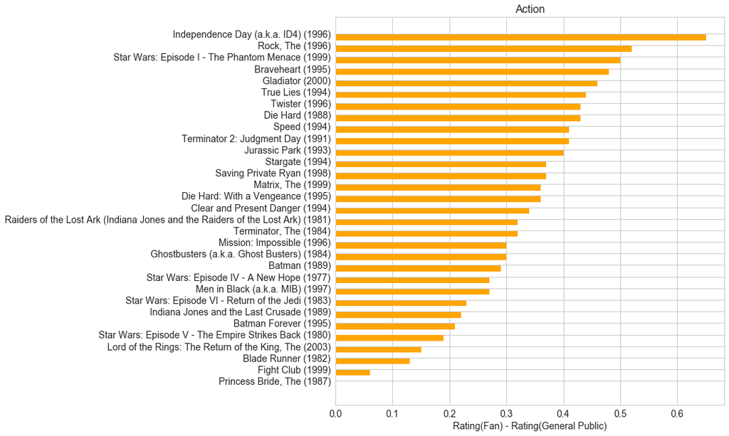

```python
Genre = GenreListAll[0]
exec('Result1 = Result'+str(Genre)+'.T')
plotGenre(Genre,Result1)
```

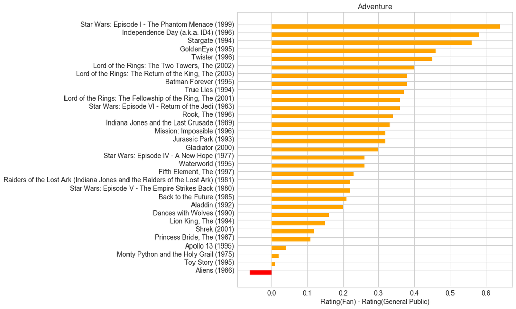

```python
Genre = GenreListAll[1]
exec('Result1 = Result'+str(Genre)+'.T')
plotGenre(Genre,Result1)
```

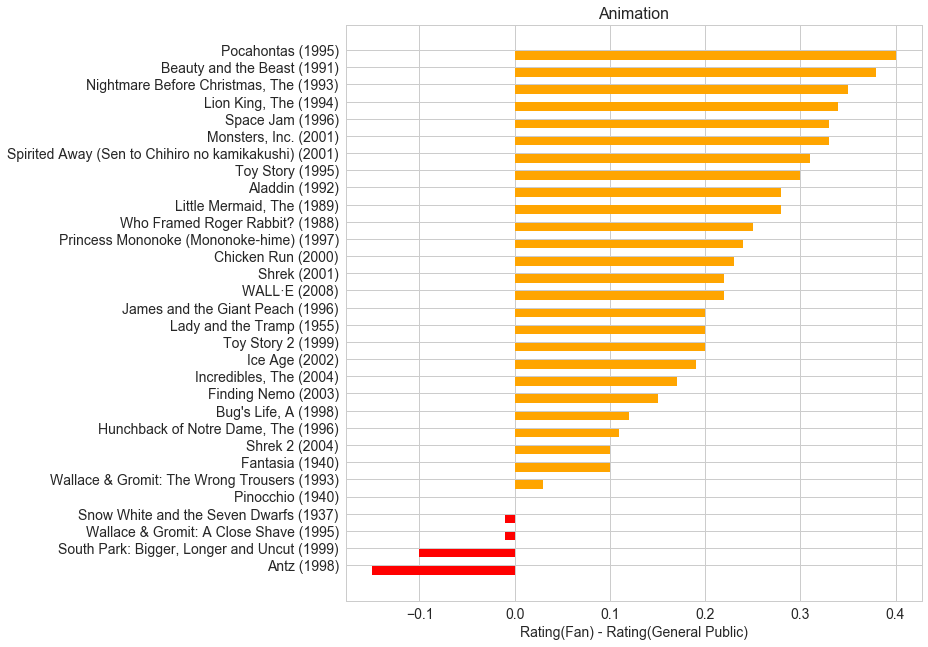

```python
Genre = GenreListAll[2]
exec('Result1 = Result'+str(Genre)+'.T')
plotGenre(Genre,Result1)
```

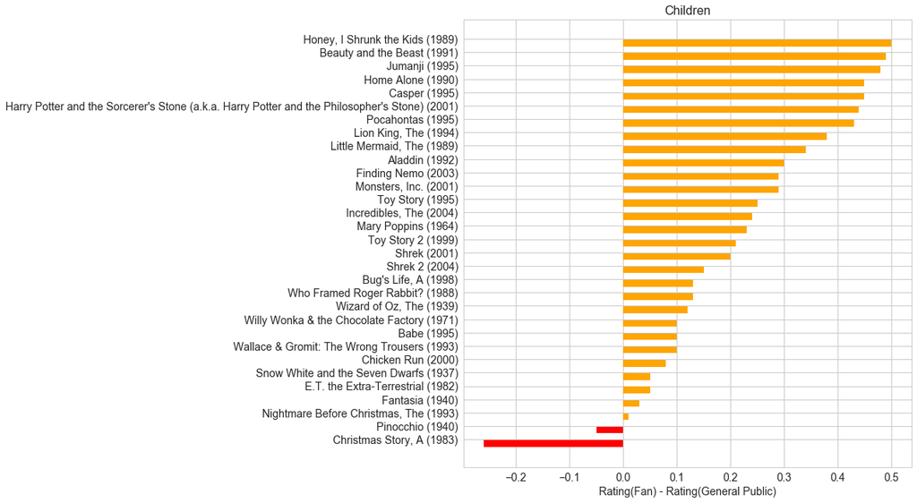

```python
Genre = GenreListAll[3]
exec('Result1 = Result'+str(Genre)+'.T')
plotGenre(Genre,Result1)
```

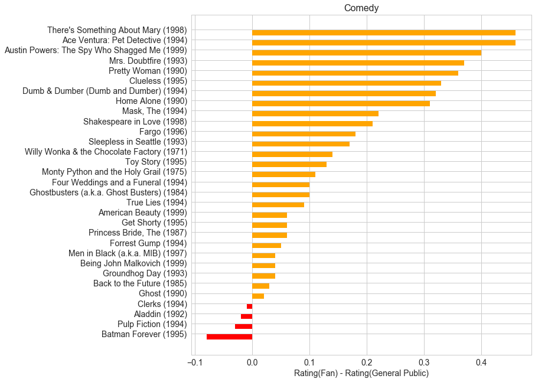

```python
Genre = GenreListAll[4]
exec('Result1 = Result'+str(Genre)+'.T')
plotGenre(Genre,Result1)
```

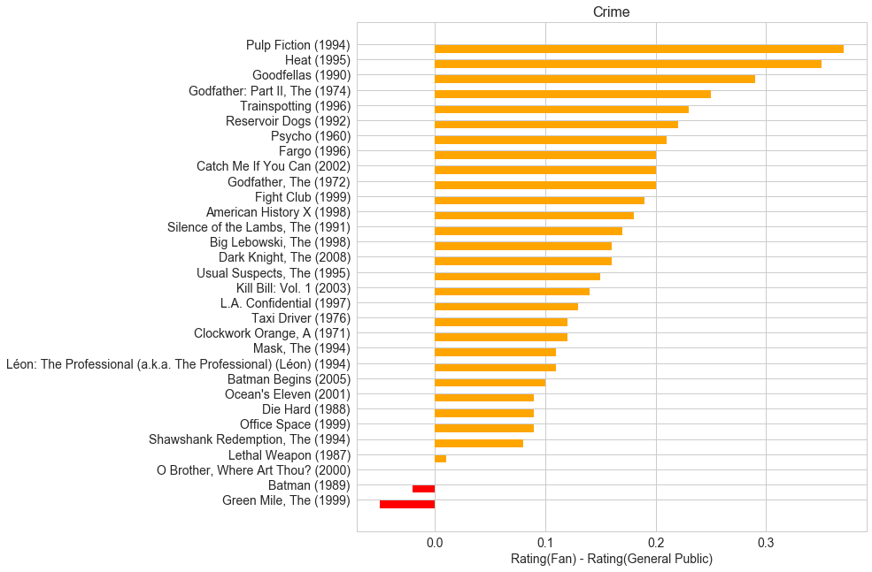

```python
Genre = GenreListAll[5]
exec('Result1 = Result'+str(Genre)+'.T')
plotGenre(Genre,Result1)
```

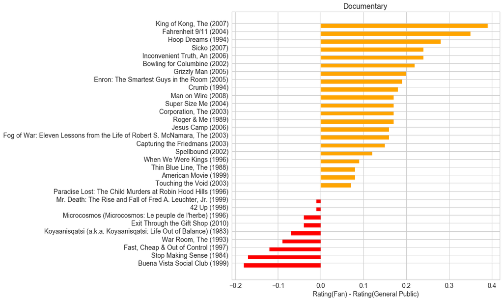

```python
Genre = GenreListAll[6]
exec('Result1 = Result'+str(Genre)+'.T')
plotGenre(Genre,Result1)
```

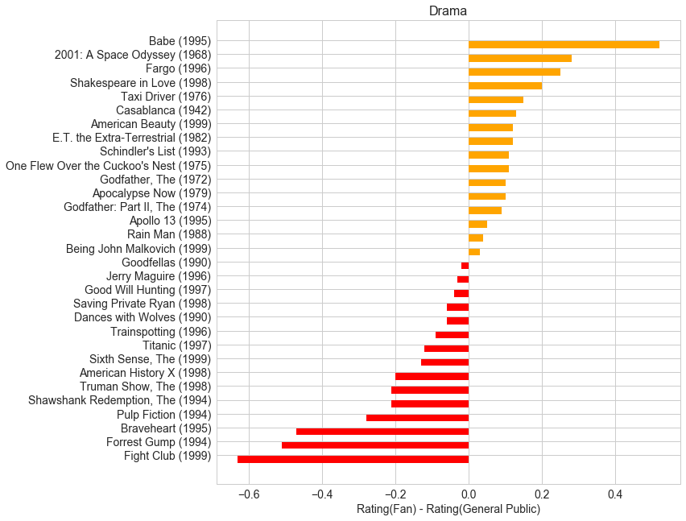

```python
Genre = GenreListAll[7]
exec('Result1 = Result'+str(Genre)+'.T')
plotGenre(Genre,Result1)
```

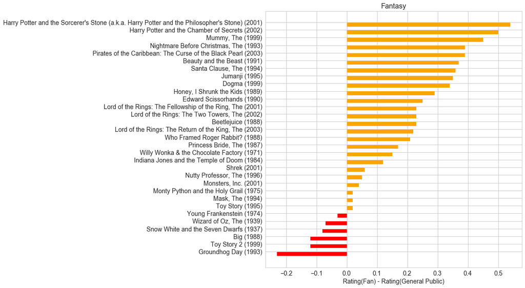

```python
Genre = GenreListAll[8]
exec('Result1 = Result'+str(Genre)+'.T')
plotGenre(Genre,Result1)
```

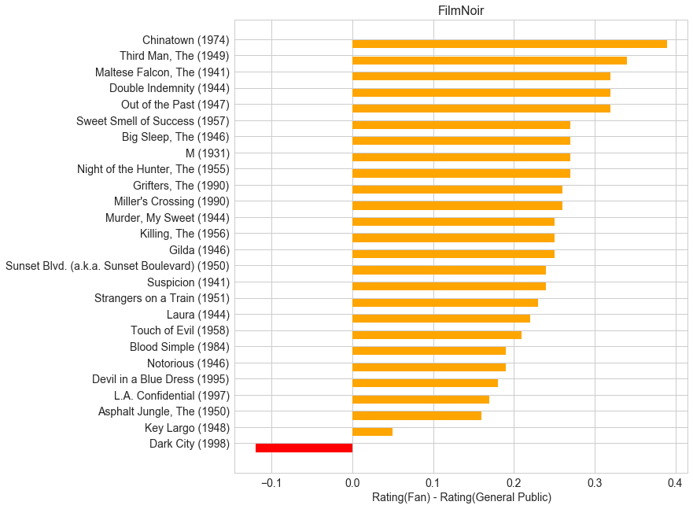

```python
Genre = GenreListAll[9]
exec('Result1 = Result'+str(Genre)+'.T')
plotGenre(Genre,Result1)
```

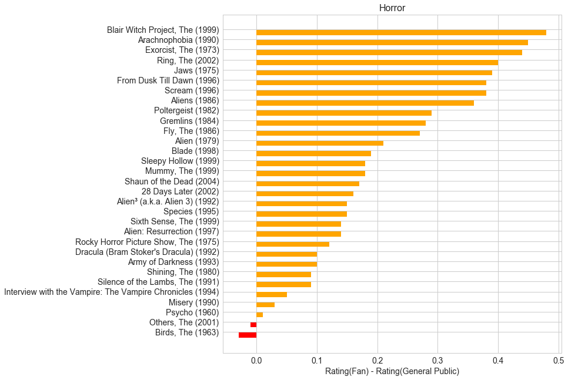

```python
Genre = GenreListAll[10]
exec('Result1 = Result'+str(Genre)+'.T')
plotGenre(Genre,Result1)
```

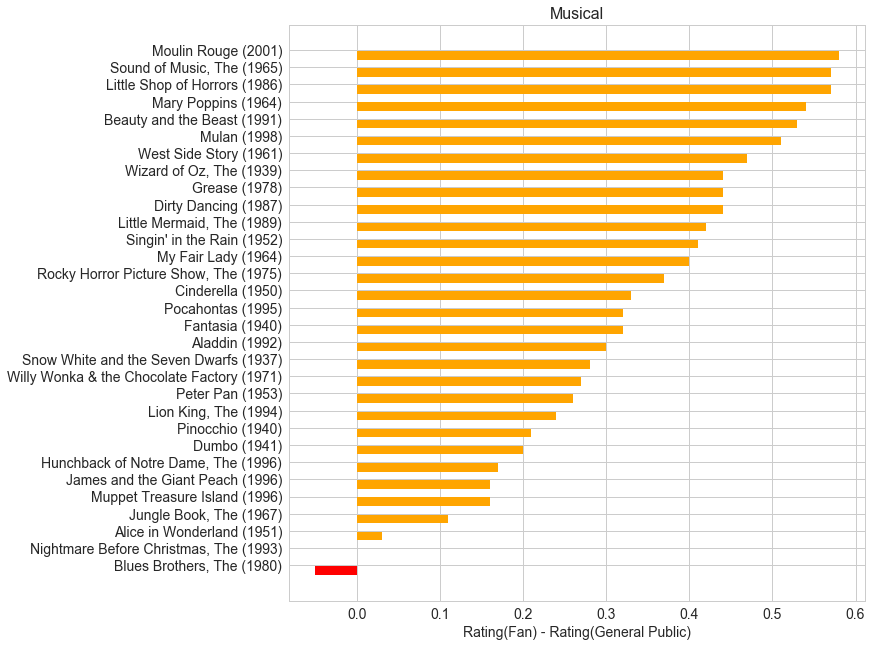

```python
Genre = GenreListAll[11]
exec('Result1 = Result'+str(Genre)+'.T')
plotGenre(Genre,Result1)
```

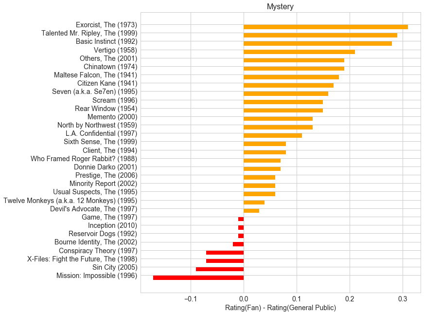

```python
Genre = GenreListAll[12]
exec('Result1 = Result'+str(Genre)+'.T')
plotGenre(Genre,Result1)
```

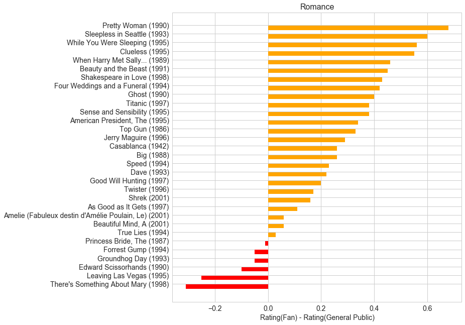

```python
Genre = GenreListAll[13]
exec('Result1 = Result'+str(Genre)+'.T')
plotGenre(Genre,Result1)
```

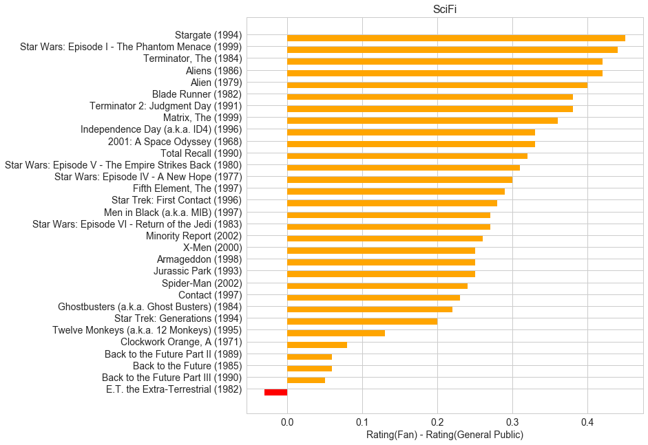

```python
Genre = GenreListAll[14]
exec('Result1 = Result'+str(Genre)+'.T')
plotGenre(Genre,Result1)
```

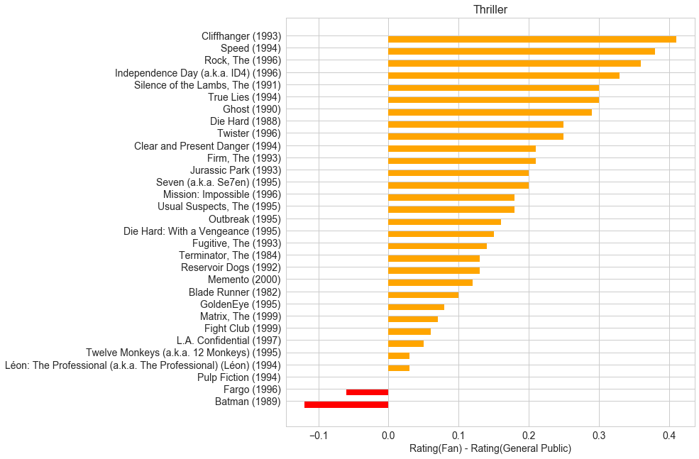

```python
Genre = GenreListAll[15]
exec('Result1 = Result'+str(Genre)+'.T')
plotGenre(Genre,Result1)
```

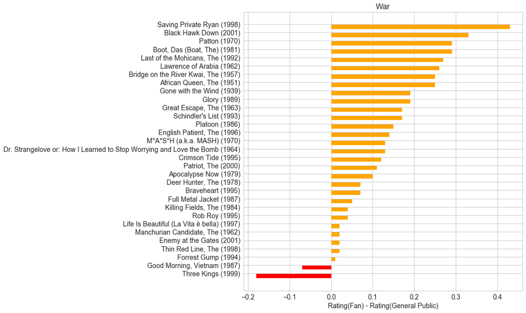

```python
Genre = GenreListAll[16]
exec('Result1 = Result'+str(Genre)+'.T')
plotGenre(Genre,Result1)
```

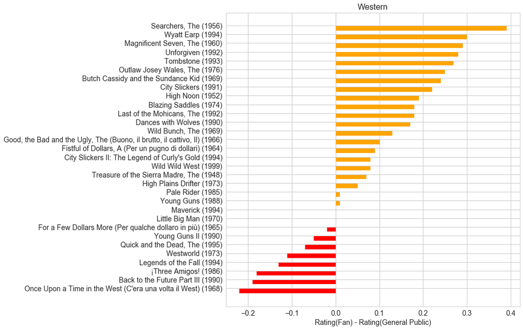

```python
Genre = GenreListAll[17]
exec('Result1 = Result'+str(Genre)+'.T')
plotGenre(Genre,Result1)
```

## Conclusion

To go back to my original question, is there bias in movie ratings? The answer is "Yes." As we can see above, the ratings of many movies will be affected by whether the person who is rating the movie is a fan of the movie's genre or not. The implication of this result is that you should be careful when checking the ratings of movies on IDMB or Rotten tomatoes, etc. A better indication of your potential interest in a movie can be determined by a more advanced movie recommendation engine, like what Netflix provides after you have rated many movies yourself, because the recommendation engine will take into account your own interests and biases.